# Supplementary Information for teff: estimation of Treatment EFFects on transcriptomic data with casual random forest

Alejandro Caceres and Juan R. González

Instituto de Salud Global de Barcelona (ISGlobal), Barcelona, Spain  
Department of Mathematics, Escola d'Enginyeria de Barcelona Est (EEBE) Universitat Politècnica de Catalunya, Barcelona Spain.  
Department of Mathematics, Universitat Autònoma de Barcelona, Barcelona, Spain

alejandro.caceres```isglobal.org

22 octubre 2021

#### Package

teff 0.1.0

# 1 Supplementary Methods

We analyzed publicly available data in the GEO repository, using the R/Bioconductor packages that can be found at . Main results are obtained from the application of the package **teff** (). The results discussed in the manuscript can be entirely reproduced with the following code.

## 1.1 Retriving data from GSE117468

We downloaded transcriptomic and clinical data from 3-phase 3 clinical trials (AMAGINE 1-2-3) as deposited in GEO on the 2nd of April of 2020 with accession number GSE117468

```r
library(GEOquery)
gsm <- getGEO("GSE117468", destdir ="./data", AnnotGPL =TRUE)
```

We first obtained clinical data relating to age, BMI, PASI, tissue (lesional or nonlesional), and brodalumab or placebo treatment. We considered all patients under two different brodalumab doses ($140 mg$ and $210 mg$).

```r
#obtain phenotype data
phenobb <- pData(phenoData(gsm[[1]]))

#patient and sample IDs
patient <- phenobb$"patientid:ch1"
id <- rownames(phenobb)

#type of visit (baseline W0 or week 12 W12)
visit <- phenobb$"visit:ch1"

#clinical data
age <- as.numeric(phenobb$"age:ch1")
bmi <- as.numeric(phenobb$"bmi:ch1")
eff <- as.numeric(phenobb$"pasi:ch1")
tissue <- phenobb$"tissue:ch1"
t <- factor(factor(phenobb$"treatment:ch1",
                   labels = c("brodalumab","brodalumab",
                              "placebo", NA)),
            levels=c("placebo", "brodalumab"))
```

We selected clinical data at baseline (BL) and transcriptomic data for non-lesional skin and stored the information in the **pheno** **data.frame**

```r
selBLN <- visit=="BL" & tissue=="non-lesional skin"
age <- age[selBLN]
bmi <- bmi[selBLN]
t <- t[selBLN]
id <- id[selBLN]
effbase <- eff[selBLN]

pheno <- data.frame(age, bmi, patient=patient[selBLN], t)
rownames(pheno) <- id

head(pheno)
```

```
##            age    bmi     patient          t
## GSM3300910  53 20.750 10216001001 brodalumab
## GSM3300916  51 35.235 10216001004    placebo
## GSM3300920  47 35.471 10216001005    placebo
## GSM3300924  49 27.898 10216001006 brodalumab
## GSM3300928  38 33.272 10216003001 brodalumab
## GSM3300932  47 36.553 10216003002    placebo
```

We selected clinical data at baseline (BL) and transcriptomic data for nonlesional skin and PASI at week 12.

```r
#obtain PASI at week 12
effend <- eff[which(visit=="W12" & tissue=="non-lesional skin")]
names(effend) <- patient[visit=="W12" & tissue=="non-lesional skin"]
effend <- effend[as.character(pheno$patient)]



#add effects
pheno <- cbind(pheno,
               eff = as.factor(effbase>effend), #response in PASI
               effdif = (effbase-effend)/effbase, #level of repose in PASI
               effbase = effbase, # PASI at baseline
               effend = effend) # PASI at week 12

#store clinical data, store in phenodat
pheno <- pheno[complete.cases(pheno),]
head(pheno)
```

```
##            age    bmi     patient          t   eff      effdif effbase effend
## GSM3300910  53 20.750 10216001001 brodalumab  TRUE  1.00000000    12.4    0.0
## GSM3300916  51 35.235 10216001004    placebo  TRUE  0.44791667    19.2   10.6
## GSM3300920  47 35.471 10216001005    placebo FALSE -0.16417910    13.4   15.6
## GSM3300928  38 33.272 10216003001 brodalumab  TRUE  0.85427136    19.9    2.9
## GSM3300932  47 36.553 10216003002    placebo FALSE -0.67980296    20.3   34.1
## GSM3300936  64 32.189 10216003003    placebo FALSE -0.08116883    30.8   33.3
```

The outcome variables were:

- effbase: PASI at baseline ($W0$)
- effend: PASI at week 12 ($W12$)
- eff: categorical improvement given by the improvement in PASI between baseline and week 12 ($W12<W0$)
- effdif: fraction of impovement of PASI from baseline ($\frac{W0-W12}{W0}$)

We then obtained the transcriptomic data for the selected individuals across 53951 transcripts.

```r
#obtain annotation data, store in genesIDs
genesIDs <- fData(gsm[[1]])

#obtain transcriptomic data, store in expr
expr <- exprs(gsm[[1]])
expr <- expr[,rownames(pheno)]

genesid <- sapply(strsplit(genesIDs$"Gene symbol", "/"), function(x) x[1])
names(genesid) <- rownames(genesIDs)
genesentrez <- genesIDs$"Gene ID"
names(genesentrez) <- rownames(genesIDs)

dim(expr)
```

```
## [1] 53951    96
```

We have the final set of individuals used in the analysis

```r
table(pheno$t)
```

```
##
##    placebo brodalumab
##         25         71
```

## 1.2 Transcriptome-wide interaction analysis

We used Bioconductor packages **limma** and **sva** to estimate the differential gene expression with the interaction between categorical PASI improvement and treatment type brodalumab or placebo. We extracted the surrogate variables with **sva** and estimated the effects of the interaction with **limma**.

We, therefore, tested the association between gene expression and the interaction between PASI improvement ($P$) and treatment ($t$) using the linear model

$$E_{ij} = \alpha_i + \beta_i (P_j \times t_j) + \sum_{r=1...k} \gamma_{ijk} C_{rj} + \epsilon_{ij}$$

where $E_{ij}$ is the post-processed transcript intensity $i$ for individual $j$ with PASI improvement $P_j$ and treatment $t_j$. $C_{rj}$ are $k$ covariates that include age, BMI and surrogate effects. $\beta_i$ was the effect of interest that measures the association between the expression level of probe $i$ and the interaction between PASI improvement and treatment. Significant genes were obtained from false discovery rates (FDR) $<0.05$ of P-values corrected for multiple comparisons.

```r
library(sva)
library(limma)

##intearaction between treatment and improvement in PASI: t*eff

#compute SVAs
mod0 <- model.matrix( ~  t + eff  + age + bmi, data = pheno)
mod <- model.matrix( ~ t:eff + t + eff  + age + bmi, data = pheno)
ns <- num.sv(expr, mod, method="be")
ss <- sva(expr, mod, mod0, n.sv=ns)$sv
```

```
## Number of significant surrogate variables is:  15
## Iteration (out of 5 ):1  2  3  4  5
```

```r
modss <- cbind(mod, ss)

#estimate associations
fit <- lmFit(expr, modss)
fit <- eBayes(fit)
```

The volcano plot showed numerous genes with significant differential expression, downregulated with the interaction. The volcano plot is obtained as follows

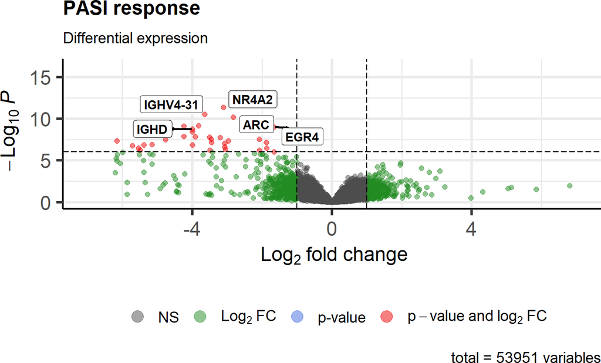

```r
library(EnhancedVolcano)

tt <- topTable(fit, coef="tbrodalumab:effTRUE", number=Inf)

gns <- genesid[rownames(tt)]
gns[11:length(gns)] <- ""
tt <- data.frame(genes=gns, tt)


EnhancedVolcano(tt, lab = tt$genes,
                selectLab  = na.omit(tt$genes[1:11]),
                x = 'logFC', y = 'P.Value',
                xlim=c(-7, 7),
                pCutoff = 0.05/nrow(tt),
                labSize = 4.0,
                labCol = 'black',
                labFace = 'bold',
                boxedLabels = TRUE,
                legendPosition = 'bottom',
                drawConnectors = TRUE,
                widthConnectors = 1,
                colConnectors = 'black',
                title = "PASI response",
                subtitle = "Differential expression")
```

We selected the association that was significant after false-discovery rate correction.

```r
tt <- topTable(fit, number=Inf, coef="tbrodalumab:effTRUE")

#Select significant associations
trascriptname <- rownames(tt)
sigGenespso <- trascriptname[tt$adj.P.Val<0.05]

tt <- data.frame(Gene= genesid[sigGenespso], tt[sigGenespso,])

tt[,c(2:4,7)] <- format(tt[,c(2:4,7)], digits=3)
tt[,5:6] <- format(tt[,5:6], digits=3, scientific=TRUE)
```

```r
head(tt,20)
```

```
##                     Gene  logFC AveExpr     t  P.Value adj.P.Val     B
## 204622_x_at        NR4A2 -3.111    6.52 -8.16 4.31e-12  2.33e-07 14.26
## 211868_x_at     IGHV4-31 -3.644    4.87 -7.73 2.95e-11  7.96e-07 12.79
## 215565_at   LOC101929272 -2.831    2.75 -7.55 6.45e-11  1.16e-06 12.19
## 210090_at            ARC -2.535    3.63 -7.34 1.62e-10  2.18e-06 11.48
## 215036_at           <NA> -2.371    4.32 -7.18 3.38e-10  3.65e-06 10.91
## 234884_x_at        CKAP2 -3.816    4.43 -7.02 6.82e-10  6.00e-06 10.36
## 217281_x_at LOC102725526 -4.245    4.51 -6.99 7.79e-10  6.00e-06 10.26
## 207768_at           EGR4 -1.658    3.50 -6.95 9.31e-10  6.28e-06 10.12
## 214973_x_at         IGHD -3.991    4.02 -6.81 1.73e-09  1.04e-05  9.63
## 217179_x_at      BMS1P20 -3.997    4.13 -6.65 3.51e-09  1.89e-05  9.08
## 217258_x_at     IGLV1-44 -4.236    4.49 -6.35 1.25e-08  6.12e-05  8.08
## 234877_x_at         <NA> -3.917    4.20 -6.32 1.42e-08  6.38e-05  7.98
## 216248_s_at        NR4A2 -3.506    6.02 -6.30 1.56e-08  6.49e-05  7.91
## 211634_x_at         IGHM -3.202    3.45 -6.26 1.85e-08  7.11e-05  7.78
## 230494_at        SLC20A1 -2.077    7.41 -6.17 2.68e-08  9.33e-05  7.48
## 204621_s_at        NR4A2 -3.459    4.43 -6.17 2.77e-08  9.33e-05  7.46
## 216984_x_at        IGLJ3 -4.766    4.87 -6.14 3.08e-08  9.78e-05  7.37
## 211881_x_at        IGLJ3 -2.972    6.10 -6.07 4.18e-08  1.25e-04  7.13
## 216401_x_at         MLIP -6.160    5.19 -6.05 4.53e-08  1.29e-04  7.07
## 234364_at          IGLL5 -1.874    3.20 -5.96 6.59e-08  1.78e-04  6.77
```

```r
library(xtable)

x <- xtable(tt,
            label="Differential expression results",
            display=c("s", "s", rep("g",6)), digits=c(0, 0, rep(3,6)))

print(x,file="./tables1.tex", floating=FALSE,
     include.rownames = TRUE, tabular.environment="longtable", caption.placement="bottom")
```

We illustrate top association by violin plots of the residuals of the log-fold change against for the categories: i) Placebo or no improvement of categorial PASI and ii) Brodalumab and improvement of PASI. The significant interaction is illustrated in the violin plots by the difference in gene transcription between those two categories.

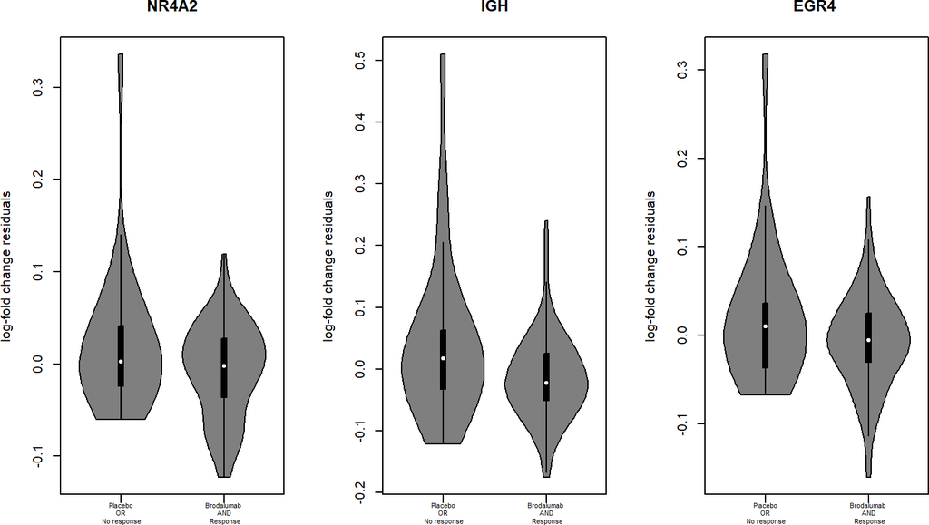

```r
library(vioplot)

par(mfrow=c(1,3))

top <- rownames(tt)[1]
tr <- log(expr[top,])
res <- summary(lm(tr~modss[,-c(1,2,3,6)]))$residuals
et <- modss[,6]
fc <- factor(modss[,6], labels=c("\n Placebo \n OR \n No response",
                                 "\n Brodalumab  \n AND \n Response"))
vioplot(res~fc, xlab="", main="NR4A2",
        ylab="log-fold change residuals", cex.names=0.5)

top <- rownames(tt)[2]
tr <- log(expr[top,])
res <- summary(lm(tr~modss[,-c(1,2,3,6)]))$residuals
et <- modss[,6]
fc <- factor(modss[,6],
             labels=c("\n Placebo \n OR \n No response",
                      "\n Brodalumab  \n AND \n Response"))
vioplot(res~fc, xlab="", main="IGH",
        ylab="log-fold change residuals", cex.names=0.5)


top <- rownames(tt)[8]
tr <- log(expr[top,])
res <- summary(lm(tr~modss[,-c(1,2,3,6)]))$residuals
et <- modss[,6]
fc <- factor(modss[,6], labels=c("\n Placebo \n OR \n No response",
                                 "\n Brodalumab  \n AND \n Response"))
vioplot(res~fc, xlab="", main="EGR4 ",
        ylab="log-fold change residuals", cex.names=0.5)
```

Enrichment analyses were performed for the molecular functions of the gene ontology terms

(http://geneontology.org/).

```r
library(clusterProfiler)

mappedgenesIds <- genesentrez[rownames(tt)]
mappedgenesIds <- unique(unlist(strsplit(mappedgenesIds, " /// ")))

#run enrichment in GO
GO <- enrichGO(gene = mappedgenesIds, 'org.Hs.eg.db',
               ont="MF", pvalueCutoff=0.05, pAdjustMethod="BH")


GO <- data.frame(ID=GO$ID, Description=GO$Description,
                 Padj=format(GO$p.adjust, digits=3, sientific=TRUE), GeneRatio=GO$GeneRatio)


head(GO)
```

```
##           ID                              Description     Padj GeneRatio
## 1 GO:0034987          immunoglobulin receptor binding 5.34e-06      5/27
## 2 GO:0003823                          antigen binding 5.34e-06      6/27
## 3 GO:0035259          glucocorticoid receptor binding 1.80e-05      3/27
## 4 GO:0035258         steroid hormone receptor binding 1.02e-04      4/27
## 5 GO:0016922                 nuclear receptor binding 2.05e-04      4/27
## 6 GO:0140297 DNA-binding transcription factor binding 2.13e-04      6/27
```

## 1.3 causal random forest

We implemented causal random forest package **grf** (https://grf-labs.github.io/grf/) for trancriptomic data in the software package **teff** (https://github.com/teff-package/teff). For installing **teff**

```r
library(devtools)
install_github("teff-package/teff")
```

We prepared feature data corresponding to the transcriptomic data of the significant transcripts identified in the previous analysis and treatment-effect data corresponding to the treatment received, categorial PSI improvement, and clinical and surrogate covariates.

```r
library(teff)

#Prepare data, features: trascription data, teff: treatment, effect and covariates
teffdata <- modss[,-c(1,6)]
colnames(teffdata)[1:2] <- c("t", "eff")
colnames(teffdata)[5:ncol(teffdata)] <- paste0("cov",5:ncol(teffdata))

psoriasis <- list(features=t(expr), teffdata=teffdata)
```

We aimed to estimate for each patient the benefit of a potential brodalumab treatment vs placebo according to their transcription data on nonlesional skin at baseline. We defined the potential effect of brodalumab treatment $\tau(p)$

A main advantage of CRF is that it can estimate the confidence interval (CI) for $\tau(p)$. We applied CRF to the transcription levels of selected genes. First, a random train-set of $80\%$ patients is drawn to grow the forest. The remaining $20\%$ of patients were set aside and not used to grow the forest. These test individuals were used to estimate their $\tau(p)$ and $95\%$ CIs according to the CRF predictor. The application of these procedures was implemented in the function **profile** of **teff**

```r
pso <-predicteff(psoriasis, featuresinf=sigGenespso, profile=TRUE, dup=TRUE, quant = 0.3)
```

We plot $\tau(p)$ with its $95\%$ CIs, using the function **plotPredict**

```r
plotPredict(pso, lb=expression(tau(p)),
            ctrl.plot = list(lb=c("Placebo", "Brodalumab"),
                             wht="topleft", whs = "bottomright"))
```

## 1.4 Logistic relation between $\tau(p)$ and observed PASI improvement

$\tau(p)$ is a measure at baseline for the estimated benefit of a potential treatment with brodalumab vs placebo. We did not observe any correlation of the prediction at baseline with future treatment or with PASI at baseline, for either treatment.

```r
treatment <- pso$treatment+1
names(treatment) <- pso$subsids

tau <- pso$predictions
names(tau) <- pso$subsids

selsubs <- names(tau)

response <- pheno[selsubs,"effdif"]
base <- pheno[selsubs,"effbase"]
bmi <- pheno[selsubs,"bmi"]
age <- pheno[selsubs,"age"]
```

```r
#association with treatment
summary(lm(log(tau/(1-tau))~treatment))
```

```r
#association with PASI at baseline in placebo
summary(lm(log(tau/(1-tau))~base, subset=which(treatment==1)))
```

```r
#association with PASI at baseline in brodalumab
summary(lm(log(tau/(1-tau))~base, subset=which(treatment==2)))
```

To assess the power of the prediction, we tested whether the prediction correlated with the observed levels do response at week 12 after treatment with brodalumab or placebo. We fitted a logistic relationship between the prediction at baseline (dose) with the observed levels of the improvement of PASI (response), given by the percentage of PASI improvement between baseline and week 12. For each treatment, We thus fitted the three-parameter logistic model:

$$PASI(\tau) = \frac{d e^{b(\log(\tau)+e)}}{1+e^{b(\log(\tau)+e)}}$$

where the lower limit is equal to $0$. $d$ is the maximum PASI improvement, $e$ the median of $\tau$ and $b$ the rate of the effect. We used the function **drm** from the package **drc**, where the rate of change $b$ is parametrized as $-b$.

```r
library(drc)

#dose-respose under placebo
dresponse <- response[treatment==1]
dtau <- tau[treatment==1]
metP <- drm(dresponse*100~dtau, fct=LL.3())
metP
```

```r
#dose-respose under brodalumab
dresponse <- response[treatment==2]
dtau <- tau[treatment==2]
metB <- drm(dresponse*100~dtau, fct=LL.3())
metB
```

We plot the fitted curves with observed values.

```r
plot(metB, log = "", pch=16, col="red", ylim=c(-100,100), xlim=c(0.2,0.45),
     ylab="% of PASI improvement at week 12",
     xlab=expression(tau(p)))

plot(metP, log = "", pch=16, col="black", ylim=c(-100,100), xlim=c(0.2,0.45),
     add=TRUE)

legend("bottomleft", legend=c("Brodalumab", "Placebo"),
       pch=16, col=c("red","black"), bty="n")
```

We tested whether there was a significant logistic relationship between $\tau$ and the levels of improvement in PASI for each treatment, using a log-likelihood test between the model and a model where the response is on average constant. We observed a strong relationship for brodalumab but not for placebo.

```r
noEffect(metB)
noEffect(metP)
```

We assessed the logistic relationship between PASI at baseline on PASI improvement after treatment.

```r
#dose-respose under placebo
dresponse <- response[treatment==1]
dbase <- base[treatment==1]
metP<-drm(dresponse*100~dbase, fct=LL.3())

dresponse <- response[treatment==2]
dbase <- base[treatment==2]
metB<-drm(dresponse*100~dbase, fct=LL.3())

noEffect(metB)
noEffect(metP)
```

```r
plot(metB, log = "", pch=16, col="red", ylim=c(-100,100), xlim=c(0,50),
     ylab="% of PASI improvement at week 12",
     xlab="PASI at baseline")

plot(metP, log = "", pch=16, col="black", ylim=c(-100,100), xlim=c(0,50),
     add=TRUE)

legend("bottomleft", legend=c("Brodalumab", "Placebo"),
       pch=16, col=c("red","black"), bty="n")
```

We assessed the logistic relationship between BMI on PASI improvement after treatment.

```r
#dose-respose under placebo
dresponse <- response[treatment==1]
dbmi <- bmi[treatment==1]
metP<-drm(dresponse*100~dbmi, fct=LL.3())

dresponse <- response[treatment==2]
dbmi <- bmi[treatment==2]
metB<-drm(dresponse*100~dbmi, fct=LL.3())

noEffect(metB)
noEffect(metP)
```

```r
plot(metB, log = "", pch=16, col="red", ylim=c(-100,100), xlim=c(20,50),
     ylab="% of PASI improvement at week 12",
     xlab="BMI (Kg/m^2)")

plot(metP, log = "", pch=16, col="black", ylim=c(-100,100), xlim=c(20,50),
     add=TRUE)

legend("bottomleft", legend=c("Brodalumab", "Placebo"),
       pch=16, col=c("red","black"), bty="n")
```

We assessed the logistic relationship between age on PASI improvement after treatment.

```r
#dose-respose under placebo
dresponse <- response[treatment==1]
dage <- age[treatment==1]
metP<-drm(dresponse*100~dage, fct=LL.3())

dresponse <- response[treatment==2]
dage <- age[treatment==2]
metB<-drm(dresponse*100~dage, fct=LL.3())

noEffect(metB)
noEffect(metP)
```

```r
plot(metB, log = "", pch=16, col="red", ylim=c(-100,100), xlim=c(20,70),
     ylab="% of PASI improvement at week 12",
     xlab="AGE (yrs)")

plot(metP, log = "", pch=16, col="black", ylim=c(-100,100), xlim=c(20,70),
     add=TRUE)

legend("bottomleft", legend=c("Brodalumab", "Placebo"),
       pch=16, col=c("red","black"), bty="n")
```

## 1.5 Targeting

We selected individuals with statistically significant $\tau(p)$ greater than 0.2. This was consistent with an significant increase PASI improvement of at least $25\%$ as given by the logistic relationship between $\tau$ and PASI imporvenemt, as described in the previuos section.

```r
dresponse <- response[treatment==1]
dtau <- tau[treatment==1]
metP <- drm(dresponse*100~dtau, fct=LL.3())
predict(metP, data.frame(dtau=0.2))
```

The function **predicteff** extracts the individuals with $\tau>0.2$ and builds the binary transcriptomic profile for individuals with high expected brodalumab benefit.

```r
pso <-predicteff(psoriasis, featuresinf=sigGenespso,
                 profile=TRUE, dup=TRUE, quant=0.5, resplevel = 0.2)

pso$profile$profpositive
```

The binary profile can be used to target individuals in other studies. To study the consistency of the targeting we first target all the individuals in the brodalumab study

```r
plotPredict(pso, lb=expression(tau(p)),
            ctrl.plot = list(lb=c("Placebo", "Brodalumab"),
                             wht="topleft", whs = "bottomright"))
```

and confirmed that the targeting significantly interacts with treatment on treatment response (**eff**). Patients in the positive group are those with high predicted benefit to brodalumab while patients in the neutral groups are with low benefit.

```r
nmf <- colnames(psoriasis$features)
nmf <- nmf[nmf%in%colnames(pso$profile$profpositive)]
ll <- genesid[nmf]
ll[is.na(ll)] <- names(ll)[is.na(ll)]

res <- target(psoriasis, pso, plot=TRUE, nmcov = c("bmi", "age"),
              effect="positive", match=0.6, model=NULL,
              lb=ll)
```

```r
library(arm)

y <- psoriasis$teffdata[,"eff"]
x <- factor(res$classification, labels=c("Low benefit", "High benefit"))
w <- psoriasis$teffdata[,"t"]

summary(bayesglm(y ~ x*w, family="binomial"))
```

We investigated biological correlates of the targeting with biological conditions relevant for psoriasis etiology. We inferred the abundance of T-cell in non-lesional skin at baseline with **immunedeconv** and correlated it with the classification of individuals into predicted high and low brodalumab benefit. We used to infer T-cell count from transcriptomic data.

```r
library(immunedeconv)

gns <- genesid[rownames(expr)]
rownames(expr) <- gns


cellcomp2 <- deconvolute(expr, "mcp_counter", arrays=TRUE,column ="Symbol")
cellnames <- cellcomp2$cell_type
cm<- matrix(as.numeric(t(cellcomp2)[-1,]), ncol=length(cellnames))
colnames(cm) <- cellnames
rownames(cm) <- colnames(cellcomp2)[-1]
tcell <- cm[,"T cell"]

boxplot(log(tcell) ~ x,
        xlab="Predicted group of Brodalumab benefit",
        ylab="T cell abuncance (log)")

summary(lm(log(tcell) ~ x[names(tcell)]))
```

```r
#########significant result
pso <-predicteff(psoriasis, featuresinf=sigGenespso,
                 profile=TRUE, dup=TRUE, quant=0.3, resplevel = 0.2)

res <- target(psoriasis, pso, plot=TRUE, nmcov = c("bmi", "age"),
              effect="positive", match=0.6, model=NULL,
              lb=ll)

x <- factor(res$classification, labels=c("Neutral", "Positive"))

summary(lm(log(tcell) ~ x))

pp <- pso$predictions

summary(lm(log(tcell[pso$subsids]) ~ pp))
```

## 1.6 Etanarcept study

We downloaded data from an entanercept study from GEO with accession number GSE11903. We retrieved transcriptomic and treatment response data for non-lesional skin at baseline.

```r
gsms1 <- getGEO("GSE11903", destdir ="./data", AnnotGPL =TRUE)
phenobb <- pData(phenoData(gsms1[[1]]))

#patient  and sample IDs
patient <- sapply(strsplit(phenobb$"title", "_"), function(x) x[[1]])
id <- rownames(phenobb)

#time of visit
visit <- phenobb$"Time:ch1"

#clinical data
eff <- as.numeric(factor(phenobb$"Group:ch1"))-1
selbase <- visit=="0" & phenobb$"Condition:ch1"=="non-lesional"
phenost1 <- data.frame(patient=patient, id=id, eff=eff)[selbase,]


rownames(phenost1) <- phenost1$id
phenost1 <- phenost1[complete.cases(phenost1),]
```

We observe 11 patients that responded after 12 weeks to the weekly administration of 50mg of etanercept

```r
head(phenost1)
table(phenost1$eff)
```

Transcriptomic data of non-lesional skin at baseline was collected with Affymetrix Human Genome U133A 2.0 Array.

```r
genesIDs <- fData(gsms1[[1]])

#obtain transcriptomic data, store in expr
expr <- exprs(gsms1[[1]])
expr <- expr[,rownames(phenost1)]

genesidS1 <- sapply(strsplit(genesIDs$"Gene symbol", "/"), function(x) x[1])
names(genesidS1) <- rownames(genesIDs)

rownames(expr) <- genesidS1

dim(expr)
```

We used transcriptomic data to infer T-cell abundance in non-lesional skin at baseline using **mcp**$\_$**counter** and fitted a regression model of response to treatment of the log-T cell levels.

```r
cellcomp2 <- deconvolute(expr, "mcp_counter", arrays=TRUE,column ="Symbol")
cellnames <- cellcomp2$cell_type
cm<- matrix(as.numeric(t(cellcomp2)[-1,]), ncol=length(cellnames))
colnames(cm) <- cellnames
rownames(cm) <- colnames(cellcomp2)[-1]
tcell <- cm[,"T cell"]

phenost1$tcell <- tcell
y <- factor(phenost1$eff, labels=c("No Response", "Response"))

boxplot(log(tcell) ~ y, ylab="T-cell abundance (log)", xlab="Observed response to Etanercept")

summary(glm(log(tcell) ~ y))
```

We formatted data for targeting individuals with high brodalumab benefit, using the profile from the GSE117468 study

```r
#compute SVAs
mod0 <- model.matrix( ~ 1, data = phenost1)
mod <- model.matrix( ~ tcell, data = phenost1)
ns <- num.sv(expr, mod, method="be")
ss <- sva(expr, mod, mod0, n.sv=ns)$sv
modss <- cbind(mod, ss)

teffdata <- modss
colnames(teffdata) <- c("t","eff", paste("cov",1:(ncol(teffdata)-2), sep=""))

rownames(expr) <- names(genesidS1)

study1 <- list(teffdata=teffdata, features=t(expr))
```

We selected common transcript IDS in the brodalumab profile and the etanercept study. We targeted individuals with available transcripts and classified them into high and low brodalumab benefit at baseline if they matched the profile in more than $60\%$ of the transcripts.

```r
nmf <- colnames(study1$features)
nmf <- nmf[nmf%in%colnames(pso$profile$profpositive)]
ll <- genesid[nmf]
ll[is.na(ll)] <- names(ll)[is.na(ll)]

res <- target(study1, pso, plot=TRUE, effect="positive", match=0.6, model=NULL, lb=ll)
```

We tested the association between the targeting and response to etanercept treatment

```r
library("epiR")

y <- phenost1$eff
x <- res$classification

tb <- table(x,y)

fisher.test(tb)

epi.tests(table(x,as.numeric(y==0)), conf.level = 0.95)
```

We finally fitted a logistic regression model of brodalumab benefit and T-cell abundancy in non-lesional skin at baseline on the observed response to a 12-week treatment with etarnecept. We computed the likelihood ratio test and the variance explained by the model ($R^2=0.751$) with the function **lrm** from **rms**.

```r
library(rms)
mod <- lrm(y ~ x + tcell, x=TRUE)
mod

prob <- predict(mod, type="fitted.ind")


d1 <- data.frame(tcell=seq(3,4,0.01),x=0)
l1 <- predict(mod, d1, type="fitted.ind")

d2 <- data.frame(tcell=seq(3,4,0.01),x=1)
l2 <- predict(mod, d2, type="fitted.ind")

plot(tcell, prob, col=x+1, pch=16, ylab="Predicted Probability of Eternacept Response")
lines(seq(3,4,0.01), l1)
lines(seq(3,4,0.01), l2, col="red")
points(tcell, y, col=x+1, pch=3)

legend(3,0.3,
       legend = c("High Brodalumab Benefit", "Low Brodalumab Benefit",
                  "Fitted Probability", "Observed Response"),
       col=c("red", "black", "black", "black"),
       pch=c(15,15,16,3),
       bty = "n")
```